# Practical Machine Learning Assignment

IcedMcstuffin

2026-04-30

# 1. Introduction

In this project, my goal will be to use data from accelerometers on the belt, forearm, arm, and dumbell of 6 participants. They were asked to perform barbell lifts correctly and incorrectly in 5 different ways. More information is available from the website [here](http://web.archive.org/web/20161224072740/http:/groupware.les.inf.puc-rio.br/har) (see the section on the Weight Lifting Exercise Dataset).

```r
library(dplyr)
library(caret)
```

# 2. Data Cleaning

Data Cleaning has been performed by collecting all the columns with accelerometer reading (20) and removing the var_accel parameters giving us 16 accelerometer predictors for 4 accelerometers on x,y,z axis and the total accelerometer reading

```r
## DATA CLEANING
# Reading the data and cleaning it to have only accelerometer columns and classe column and setting classe to factor class
rawtraining <- read.csv("pml-training.csv")
acceltraining <- select(rawtraining, contains(c("accel", "classe")))
acceltraining$classe <- as.factor(acceltraining$classe)
training <- acceltraining[,-c(2,7,12,17)]
training$classe <- as.factor(training$classe)

rawtesting <- read.csv("pml-testing.csv")
acceltesting <- select(rawtesting, contains("accel"))
testing <- acceltesting[,-c(2,7,12,17)]
```

# 3. Model Selection

Since there are 5 possible outcomes, we will be checking the random forest predictor model, gradient boosting model and assessing each of its accuracy

For all the test, a 5 fold cross validation is performed by trainControl() function as the training data set has large number of osbervations - 19622.

## 3.1 Random Forest model

```r
set.seed(3223)
rfmodel <- train(classe~., data=training, method="rf", trControl = trainControl(method = "cv", number = 5))
print(rfmodel)
```

```
## Random Forest
##
## 19622 samples
##    16 predictor
##     5 classes: 'A', 'B', 'C', 'D', 'E'
##
## No pre-processing
## Resampling: Cross-Validated (5 fold)
## Summary of sample sizes: 15697, 15697, 15696, 15699, 15699
## Resampling results across tuning parameters:
##
##   mtry  Accuracy   Kappa
##    2    0.9518915  0.9391218
##    9    0.9454189  0.9309310
##   16    0.9338505  0.9162942
##
## Accuracy was used to select the optimal model using the largest value.
## The final value used for the model was mtry = 2.
```

This shows that the expected out-of-sample accuracy of this model is 0.95 and the error rate is 5%

This is the plot for the Variable importance of each of the predictor.

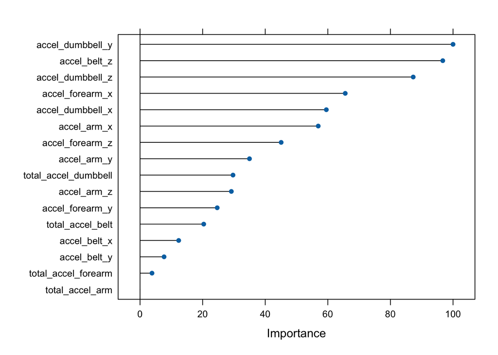

```r
plot(varImp(rfmodel))
```

## 3.2 Gradient Boosting model

```r
set.seed(3223)
gbmModel <- train(classe~., data=training, method="gbm", trControl = trainControl(method = "cv", number = 5), verbose = FALSE)
print(gbmModel)
```

```
## Stochastic Gradient Boosting
##
## 19622 samples
##    16 predictor
##     5 classes: 'A', 'B', 'C', 'D', 'E'
##
## No pre-processing
## Resampling: Cross-Validated (5 fold)
## Summary of sample sizes: 15697, 15697, 15696, 15699, 15699
## Resampling results across tuning parameters:
##
##   interaction.depth  n.trees  Accuracy   Kappa
##   1                   50      0.5504525  0.4225117
##   1                  100      0.6027412  0.4919915
##   1                  150      0.6380589  0.5380158
##   2                   50      0.6676691  0.5755302
##   2                  100      0.7371324  0.6655665
##   2                  150      0.7734194  0.7122530
##   3                   50      0.7316793  0.6585579
##   3                  100      0.7938044  0.7382137
##   3                  150      0.8257065  0.7790526
##
## Tuning parameter 'shrinkage' was held constant at a value of 0.1
##
## Tuning parameter 'n.minobsinnode' was held constant at a value of 10
## Accuracy was used to select the optimal model using the largest value.
## The final values used for the model were n.trees = 150, interaction.depth =
##  3, shrinkage = 0.1 and n.minobsinnode = 10.
```

# 4. Conclusion

After comparing the accuracy of these models, we will choose to select the model because of its out of sample accuracy of 95%